| title: “Survey sample size planning with svyplan” |
| --- |
| output: rmarkdown::html_vignette |
| vignette: > |
| % |
| % |
| % |

`svyplan` provides a simple and complete toolkit for survey sample size determination. It covers sample sizes for proportions and means, precision analysis, multistage cluster allocation, multi-indicator optimization, strata boundary optimization, and power analysis. All functions share a consistent interface built around `S3` generics, enabling round-trip conversions between sample size and precision, and sensitivity analysis via `predict()`.

## Function ecosystem

The package exports 14 functions organized into five families. The diagram below shows how they relate to each other.

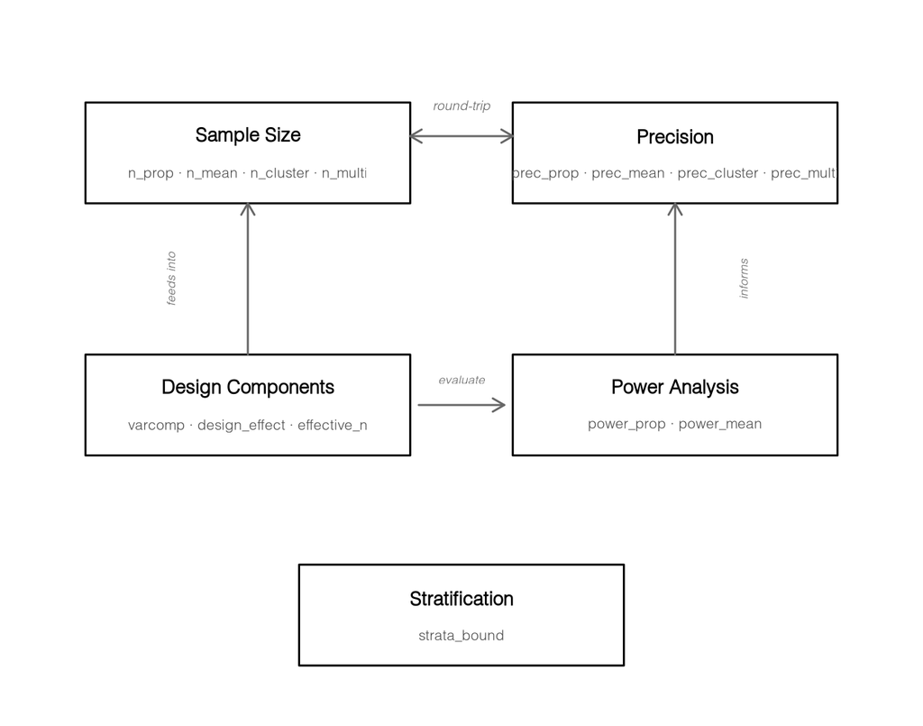

| Family | Functions | Purpose |
| --- | --- | --- |
| Sample size | `n_prop`, `n_mean`, `n_cluster`, `n_multi` | “How many units do I need?” |
| Precision | `prec_prop`, `prec_mean`, `prec_cluster`, `prec_multi` | “What precision does *n* achieve?” |
| Power | `power_prop`, `power_mean` | “Can I detect a change?” |
| Design | `varcomp`, `design_effect`, `effective_n` | Variance components and design effects |
| Strata | `strata_bound` | Optimal stratification boundaries |

Every function returns an S3 object with `print`, `summary`, `predict`, and (where applicable) `confint` methods.

## The n_*/prec_* duality

The most distinctive feature of svyplan is the bidirectional link between sample size and precision functions. Every `n_*` function has a `prec_*` counterpart, and they are exact inverses.

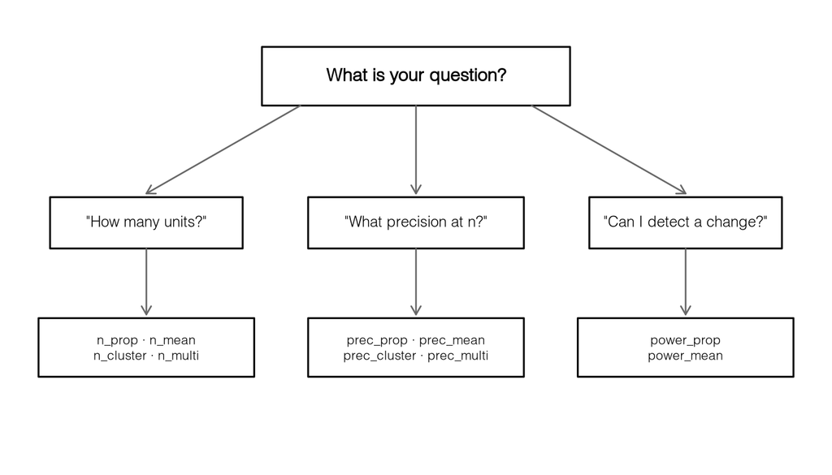

Because `n_*` and `prec_*` are S3 generics, you can pass a result object directly to its inverse. All design parameters travel with the object:

```r
# Compute sample size for a proportion
s <- n_prop(p = 0.3, moe = 0.05, deff = 1.5)
s
```

```
#> Sample size for proportion (wald)
#> n = 485 (p = 0.30, moe = 0.050, deff = 1.50)
```

```r
# What precision does this n achieve?
p <- prec_prop(s)
p
```

```
#> Sampling precision for proportion (wald)
#> n = 485
#> se = 0.0255, moe = 0.0500, cv = 0.0850
```

```r
# Recover the original sample size
n_prop(p)
```

```
#> Sample size for proportion (wald)
#> n = 485 (p = 0.30, moe = 0.050, deff = 1.50)
```

You can also override a parameter on the way back:

```r
n_prop(p, cv = 0.08)
```

```
#> Sample size for proportion (wald)
#> n = 547 (p = 0.30, cv = 0.080, deff = 1.50)
```

## Sample sizes for proportions and means

### Proportions

Estimate vaccination coverage (expected ~70%) with a 5 percentage point margin of error:

```r
n_prop(p = 0.70, moe = 0.05)
```

```
#> Sample size for proportion (wald)
#> n = 323 (p = 0.70, moe = 0.050)
```

Three method options control how the margin of error is computed:

- **`"wald"`** (default): the textbook normal approximation
- **`"wilson"`**: Wilson score interval, better coverage near 0 or 1
- **`"logodds"`**: log-odds transformation, recommended for rare events

```r
n_prop(p = 0.05, moe = 0.02, method = "wald")
```

```
#> Sample size for proportion (wald)
#> n = 457 (p = 0.05, moe = 0.020)
```

```r
n_prop(p = 0.05, moe = 0.02, method = "wilson")
```

```
#> Sample size for proportion (wilson)
#> n = 469 (p = 0.05, moe = 0.020)
```

```r
n_prop(p = 0.05, moe = 0.02, method = "logodds")
```

```
#> Sample size for proportion (logodds)
#> n = 475 (p = 0.05, moe = 0.020)
```

Target a coefficient of variation instead of a margin of error:

```r
n_prop(p = 0.70, cv = 0.05)
```

```
#> Sample size for proportion (wald)
#> n = 172 (p = 0.70, cv = 0.050)
```

### Means

Estimate average household expenditure (variance = 40,000, mean = 800) with a margin of error of 30:

```r
n_mean(var = 40000, moe = 30)
```

```
#> Sample size for mean
#> n = 171 (var = 40000.00, moe = 30.000)
```

### Common parameters

All `n_*` and `prec_*` functions accept:

| Parameter | Meaning |
| --- | --- |
| `deff` | Design effect multiplier (default 1) |
| `N` | Finite population size (enables FPC correction) |
| `alpha` | Significance level (default 0.05) |
| `resp_rate` | Expected response rate (inflates *n* by `1/resp_rate`) |

```r
n_prop(p = 0.70, moe = 0.05, deff = 1.5, N = 50000, resp_rate = 0.85)
```

```
#> Sample size for proportion (wald)
#> n = 566 (net: 481) (p = 0.70, moe = 0.050, deff = 1.50, resp_rate = 0.85)
```

The design effect can be less than 1 for efficient designs (e.g. well-stratified or PPS samples). svyplan accepts any `deff > 0`.

## Evaluating precision

The `prec_*()` functions answer the reverse question: given a fixed sample size, what precision can you achieve?

```r
prec_prop(p = 0.3, n = 400)
```

```
#> Sampling precision for proportion (wald)
#> n = 400
#> se = 0.0229, moe = 0.0449, cv = 0.0764
```

```r
prec_mean(var = 40000, n = 300, mu = 800)
```

```
#> Sampling precision for mean
#> n = 300
#> se = 11.5470, moe = 22.6317, cv = 0.0144
```

Design parameters work identically:

```r
prec_prop(p = 0.3, n = 400, deff = 1.5, resp_rate = 0.85)
```

```
#> Sampling precision for proportion (wald)
#> n = 400 (net: 340)
#> se = 0.0304, moe = 0.0597, cv = 0.1015
```

### Confidence intervals

`confint()` extracts the expected confidence interval from any sample size or precision object:

```r
s <- n_prop(p = 0.3, moe = 0.05)
confint(s)
```

```
#>  2.5 % 97.5 %
#>   0.25   0.35
```

```r
pr <- prec_prop(p = 0.3, n = 400)
confint(pr)
```

```
#>      2.5 %    97.5 %
#>  0.2550916 0.3449084
```

```r
confint(pr, level = 0.99)
```

```
#>      0.5 %    99.5 %
#>  0.2409803 0.3590197
```

For proportions, the interval is clamped to [0, 1].

## Multi-indicator surveys

Household surveys like Demographic and Health Surveys (DHS) or Multiple Indicator Cluster Survey (MICS) track many indicators simultaneously. Each indicator has its own expected prevalence, precision target, and design effect. `n_multi()` finds the sample size that satisfies all targets at once.

```r
targets <- data.frame(
  name = c("stunting", "vaccination", "anemia"),
  p    = c(0.25, 0.70, 0.12),
  moe  = c(0.05, 0.05, 0.03),
  deff = c(2.0, 1.5, 2.5)
)

n_multi(targets)
```

```
#> Multi-indicator sample size
#> n = 1127 (binding: anemia)
#> ---
#>  name        .n   .binding
#>  stunting     577
#>  vaccination  485
#>  anemia      1127 *
```

### Achieved precision

```r
plan <- n_multi(targets)
prec_multi(plan)
```

```
#> Multi-indicator sampling precision
#>  name        .se        .moe .cv
#>  stunting    0.02551067 0.05 0.10204269
#>  vaccination 0.02551067 0.05 0.03644382
#>  anemia      0.01530640 0.03 0.12755336
```

### Domain targets

Surveys often need adequate precision within subpopulations (urban/rural, regions). Add domain columns to the targets data frame and `n_multi()` optimizes each domain separately:

```r
targets_dom <- data.frame(
  name       = rep(c("stunting", "vaccination", "anemia"), each = 2),
  residence  = rep(c("urban", "rural"), 3),
  p          = c(0.18, 0.32, 0.80, 0.60, 0.08, 0.16),
  moe        = c(0.05, 0.05, 0.05, 0.05, 0.03, 0.03),
  deff       = c(1.5, 2.5, 1.2, 1.8, 2.0, 3.0)
)

n_multi(targets_dom)
```

```
#> Treating column(s) 'residence' as domain variable(s)
#> Multi-indicator sample size (2 domains)
#> n = 1721 (binding: anemia)
#> ---
#>  residence .n   .binding
#>  rural     1721 anemia
#>  urban      629 anemia
```

Any column not recognized as a standard parameter (`name`, `p`, `moe`, `deff`, etc.) is automatically treated as a domain variable.

### Minimum sample size per domain

The `min_n` parameter sets a floor for the per-domain sample size:

```r
n_multi(targets_dom, min_n = 300)
```

```
#> Treating column(s) 'residence' as domain variable(s)
#> Multi-indicator sample size (2 domains, min_n = 300)
#> n = 1721 (binding: anemia)
#> ---
#>  residence .n   .binding
#>  rural     1721 anemia
#>  urban      629 anemia
```

### Mixing proportions and means

Targets can mix proportion and mean indicators. Use `var` and `mu` columns for means (leave `p` as `NA`), and `p` for proportions (leave `var`/`mu` as `NA`):

```r
targets_mixed <- data.frame(
  name = c("vaccination", "expenditure"),
  p    = c(0.70, NA),
  var  = c(NA, 40000),
  mu   = c(NA, 800),
  cv   = c(0.05, 0.10),
  deff = c(1.5, 2.0)
)

n_multi(targets_mixed)
```

```
#> Multi-indicator sample size
#> n = 258 (binding: vaccination)
#> ---
#>  name        .n  .binding
#>  vaccination 258 *
#>  expenditure  13
```

## Multistage cluster designs

For two-stage or three-stage designs, the question is not just “how many?” but “how many clusters and how many units per cluster?” The answer depends on the cost structure and the degree of clustering.

### Variance components from frame data

If frame data with cluster identifiers is available, `varcomp()` estimates between-cluster and within-cluster variance components:

```r
set.seed(1)
n_clust <- 80
n_hh <- 15
cluster_id <- rep(seq_len(n_clust), each = n_hh)
cluster_mean <- rnorm(n_clust, mean = 50, sd = 10)
expenditure <- cluster_mean[cluster_id] + rnorm(n_clust * n_hh, sd = 20)
frame <- data.frame(cluster = cluster_id, expenditure = expenditure)

vc <- varcomp(expenditure ~ cluster, data = frame)
vc
```

```
#> Variance components (2-stage)
#> var_between = 0.0398, var_within = 0.1700
#> delta = 0.1896
#> k = 1.0589
#> Unit relvariance = 0.1981
```

The `delta` value is the measure of homogeneity (intraclass correlation). It feeds directly into `n_cluster()` and `design_effect()`.

### Optimal two-stage allocation

Given per-stage costs and the variance structure, `n_cluster()` finds the allocation that either minimizes cost for a target CV, or minimizes CV for a given budget:

```r
# Minimize cost to achieve CV = 0.05
n_cluster(cost = c(500, 50), delta = vc, cv = 0.05)
```

```
#> Optimal 2-stage allocation
#> Stage 1: n1 = 27 | Stage 2: n2 = 7 -> total n = 189
#> cv = 0.0500, cost = 21751
```

```r
# Maximize precision within a budget
n_cluster(cost = c(500, 50), delta = vc, budget = 100000)
```

```
#> Optimal 2-stage allocation
#> Stage 1: n1 = 121 | Stage 2: n2 = 7 -> total n = 847
#> cv = 0.0233, cost = 100000
```

Passing `delta = vc` (the varcomp object) automatically extracts `delta`, `rel_var`, and `k`.

### Three-stage designs

Add a third cost element and a second delta for three-stage designs:

```r
n_cluster(
  cost  = c(1000, 200, 20),
  delta = c(0.01, 0.05),
  cv    = 0.05
)
```

```
#> Optimal 3-stage allocation
#> Stage 1: n1 = 14 | Stage 2: n2 = 6 | Stage 3: n3 = 14 -> total n = 1176
#> cv = 0.0500, cost = 45654
```

### Response rate in cluster designs

In budget mode, applying a response rate does not change the allocation (the budget constrains the design); instead, the achieved CV worsens. In CV mode, the first-stage sample is inflated by `1/resp_rate`:

```r
n_cluster(cost = c(500, 50), delta = vc, cv = 0.05, resp_rate = 0.90)
```

```
#> Optimal 2-stage allocation
#> Stage 1: n1 = 30 | Stage 2: n2 = 7 -> total n = 210 (net: 189)
#> cv = 0.0500, cost = 24168
```

### Fixed overhead costs

```r
# Budget mode: fixed overhead reduces the allocatable budget
n_cluster(cost = c(500, 50), delta = vc, budget = 100000, fixed_cost = 5000)
```

```
#> Optimal 2-stage allocation
#> Stage 1: n1 = 115 | Stage 2: n2 = 7 -> total n = 805
#> cv = 0.0239, cost = 100000 (fixed: 5000)
```

```r
# CV mode: same allocation, cost increases by fixed_cost
n_cluster(cost = c(500, 50), delta = vc, cv = 0.05, fixed_cost = 5000)
```

```
#> Optimal 2-stage allocation
#> Stage 1: n1 = 27 | Stage 2: n2 = 7 -> total n = 189
#> cv = 0.0500, cost = 26751 (fixed: 5000)
```

The same parameter is available in `n_multi()` for multistage multi-indicator designs.

### Evaluating cluster allocations

`prec_cluster()` computes the achieved CV for any allocation:

```r
alloc <- n_cluster(cost = c(500, 50), delta = vc, budget = 100000)
prec_cluster(alloc)
```

```
#> Sampling precision for 2-stage cluster
#> n1 = 121 | n2 = 7 -> total n = 847
#> cv = 0.0233
```

```r
# Arbitrary allocation
prec_cluster(n = c(50, 12), delta = 0.05)
```

```
#> Sampling precision for 2-stage cluster
#> n1 = 50 | n2 = 12 -> total n = 600
#> cv = 0.0508
```

### Design effects

The cluster design effect formula `deff = 1 + (m - 1) * delta` links cluster size to precision loss:

```r
design_effect(delta = 0.05, m = 20, method = "cluster")
```

```
#> [1] 1.95
```

After data collection, compute the realized design effect from survey weights:

```r
set.seed(123)
w <- runif(500, 0.5, 4)
design_effect(w, method = "kish")
```

```
#> [1] 1.198255
```

```r
effective_n(w, method = "kish")
```

```
#> [1] 417.2735
```

### Multi-indicator multistage

For surveys with multiple indicators in a cluster design, provide `delta` columns and a cost/budget to `n_multi()`:

```r
targets_ms <- data.frame(
  name   = c("stunting", "vaccination"),
  p      = c(0.25, 0.70),
  cv     = c(0.10, 0.08),
  delta1 = c(0.05, 0.02)
)

n_multi(targets_ms, cost = c(500, 50), budget = 80000)
```

```
#> Multi-indicator optimal allocation (2-stage)
#> n1 = 68 | n2 = 14 -> total n = 952
#> cv = 0.0728, cost = 80000 (binding: stunting)
#> ---
#>  name        .cv_target .cv_achieved .binding
#>  stunting    0.10       0.0728       *
#>  vaccination 0.08       0.0241
```

## Optimal strata boundaries

When a continuous auxiliary variable is available on the frame, `strata_bound()` finds the cut points that minimize the sample size (or CV) for a given number of strata.

```r
set.seed(12345)
x <- rlnorm(5000, meanlog = 6, sdlog = 1.2)

strata_bound(x, n_strata = 4, n = 300, method = "cumrootf")
```

```
#> Strata boundaries (Dalenius-Hodges, 4 strata)
#> Boundaries: 400.0, 1200.0, 3100.0
#> n = 300, cv = 0.0199
#> ---
#>  stratum lower       upper    N_h  W_h   S_h    n_h
#>  1          3.826706   400.00 2473 0.495 105.3   48
#>  2        400.000000  1200.00 1647 0.329 222.7   68
#>  3       1200.000000  3100.00  672 0.134 519.5   65
#>  4       3100.000000 21957.85  208 0.042 3094.3 119
```

Four methods are available:

| Method | Algorithm | Speed | Best for |
| --- | --- | --- | --- |
| `"cumrootf"` | Dalenius-Hodges cumulative root frequency | Fast | General use |
| `"geo"` | Geometric progression | Fast | Skewed data |
| `"lh"` | Lavall0e9e-Hidiroglou iterative | Moderate | Skewed data |
| `"kozak"` | Kozak random search | Slow | Global optimum |

The Kozak method often finds better boundaries for highly skewed distributions:

```r
strata_bound(x, n_strata = 4, cv = 0.05, method = "kozak")
```

```
#> Strata boundaries (Kozak, 4 strata)
#> Boundaries: 405.6, 1219.3, 3447.4
#> n = 59, cv = 0.0500
#> ---
#>  stratum lower       upper      N_h  W_h   S_h    n_h
#>  1          3.826706   405.6271 2494 0.499 106.6  10
#>  2        405.627119  1219.2788 1645 0.329 226.7  14
#>  3       1219.278753  3447.3536  690 0.138 589.2  15
#>  4       3447.353550 21957.8496  171 0.034 3206.8 20
```

### Allocation methods

Allocation within strata is controlled by the `alloc` parameter:

- `"proportional"`: allocate proportional to stratum size
- `"neyman"`: allocate proportional to `N_h * S_h` (minimizes variance)
- `"optimal"`: allocate proportional to `N_h * S_h / sqrt(c_h)` (accounts for costs)
- Custom: pass `list(q1 = ..., q2 = ..., q3 = ...)` for the formula `N_h^q1 * S_h^q2 / c_h^q3`

### Classifying new observations

`predict()` applies the learned boundaries to new data, returning a factor:

```r
sb <- strata_bound(x, n_strata = 4, n = 200, method = "cumrootf")
new_x <- c(100, 500, 1500, 5000)
predict(sb, newdata = new_x, labels = paste0("S", 1:4))
```

```
#> [1] S1 S2 S3 S4
#> Levels: S1 S2 S3 S4
```

### Visualizing allocation

`plot()` shows the sampling fraction per stratum. Under Neyman allocation, high-variance strata are sampled more intensively. The dashed line marks the overall fraction:

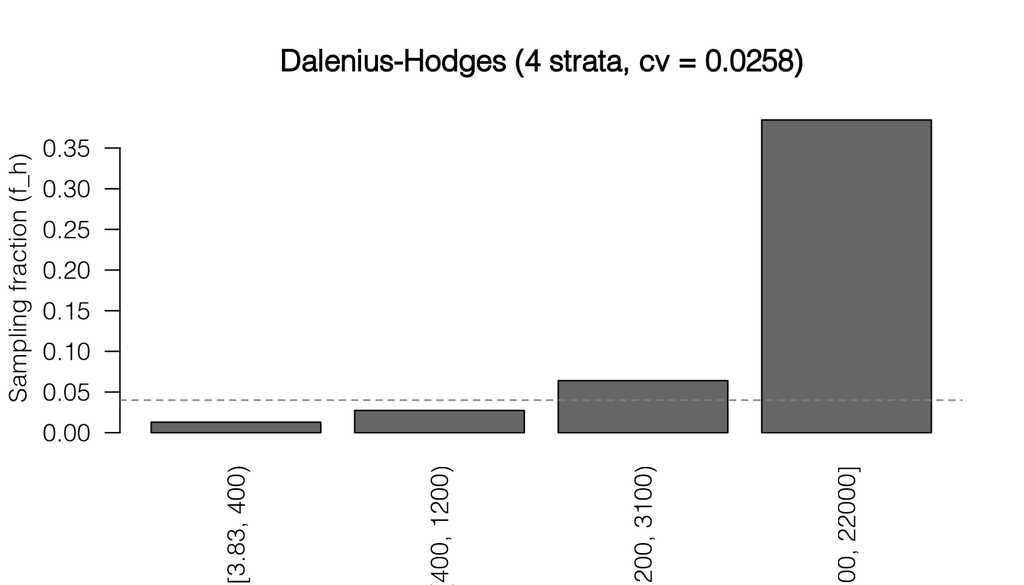

```r
plot(sb)
```

## Power analysis

Precision analysis answers “how precisely can we estimate a level?” Power analysis answers a different question: “can we detect a change or difference between two groups or time points?”

### Sample size for a detectable change

A survey measured vaccination coverage at 70%. How many households are needed in a follow-up to detect a 5 percentage point increase with 80% power?

```r
power_prop(p1 = 0.70, p2 = 0.75, power = 0.80)
```

```
#> Power analysis for proportions (solved for sample size)
#> n = 1248 (per group), power = 0.800, delta = 0.0500
#> (p1 = 0.700, p2 = 0.750, alpha = 0.05)
```

With a design effect:

```r
power_prop(p1 = 0.70, p2 = 0.75, power = 0.80, deff = 2.0)
```

```
#> Power analysis for proportions (solved for sample size)
#> n = 2496 (per group), power = 0.800, delta = 0.0500
#> (p1 = 0.700, p2 = 0.750, alpha = 0.05, deff = 2.00)
```

### Three solve modes

`power_prop()` and `power_mean()` each solve for whichever of `n`, `power`, or the effect size is left unspecified:

```r
# Solve for n (default when p2 and power given)
power_prop(p1 = 0.70, p2 = 0.75, power = 0.80, deff = 2.0)
```

```
#> Power analysis for proportions (solved for sample size)
#> n = 2496 (per group), power = 0.800, delta = 0.0500
#> (p1 = 0.700, p2 = 0.750, alpha = 0.05, deff = 2.00)
```

```r
# Solve for power (set power = NULL)
power_prop(p1 = 0.70, p2 = 0.75, n = 1500, power = NULL, deff = 2.0)
```

```
#> Power analysis for proportions (solved for power)
#> n = 1500 (per group), power = 0.584, delta = 0.0500
#> (p1 = 0.700, p2 = 0.750, alpha = 0.05, deff = 2.00)
```

```r
# Solve for MDE (omit p2)
power_prop(p1 = 0.70, n = 1500, deff = 2.0)
```

```
#> Power analysis for proportions (solved for minimum detectable effect)
#> n = 1500 (per group), power = 0.800, delta = 0.0639
#> (p1 = 0.700, p2 = 0.764, alpha = 0.05, deff = 2.00)
```

### Panel surveys

If the follow-up resamples a fraction of the original households and the between-round correlation is known, the required sample size drops:

```r
power_prop(p1 = 0.70, p2 = 0.75, power = 0.80, deff = 2.0,
           overlap = 0.50, rho = 0.6)
```

```
#> Power analysis for proportions (solved for sample size)
#> n = 1749 (per group), power = 0.800, delta = 0.0500
#> (p1 = 0.700, p2 = 0.750, alpha = 0.05, deff = 2.00, overlap = 0.50, rho = 0.60)
```

### Continuous outcomes

The same three solve modes work for means:

```r
# Sample size to detect a difference of 5 (within-group var = 200)
power_mean(delta = 5, var = 200)
```

```
#> Power analysis for means (solved for sample size)
#> n = 126 (per group), power = 0.800, delta = 5.0000
#> (alpha = 0.05)
```

```r
# MDE with n = 400 per group
power_mean(var = 200, n = 400)
```

```
#> Power analysis for means (solved for minimum detectable effect)
#> n = 400 (per group), power = 0.800, delta = 2.8016
#> (alpha = 0.05)
```

### Power curve

`plot()` draws the power-vs-sample-size curve with reference lines at the solved point:

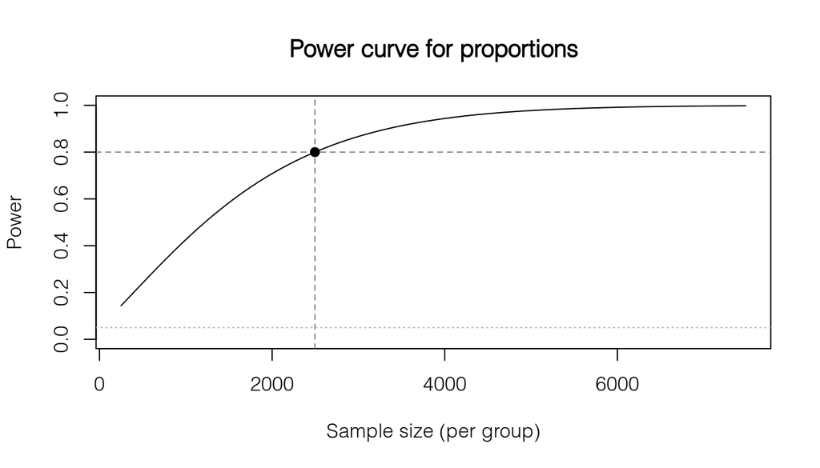

```r
pw <- power_prop(p1 = 0.70, p2 = 0.75, power = 0.80, deff = 2.0)
plot(pw)
```